- ```
  ("PCOS" OR "polycystic ovary syndrome" OR "Stein-Leventhal syndrome" OR "sclerocystic ovarian degeneration" OR "sclerocystic ovaries" OR "sclerocystic ovary syndrome") AND ("granulosa cells" OR "GC" OR "cumulus cells" OR "granulosa cumulus cells") AND ("human" OR "homo sapiens")
  ```

- **ranseq**
  - **GSE138518**
    - Illumina NovaSeq 6000 (Homo sapiens)
    - 3vs3
    - RNA sequencing in ovarian granulosa cells of PCOS patients and normal people
  - **GSE155489**
    - HiSeq X Ten (Homo sapiens)
    - 4vs4
    - GCs from three PCOS patients and compared them with age-matched, women without PCOS, and performed RNA sequencing analysis to explore the transcriptional characteristics of their oocytes and GCs
  - GSE173160 - 不行是lncRna
  - **GSE193123**
    - Illumina NovaSeq 6000 (Homo sapiens)
    - 3vs3
    - Granulosa cells collected from two individuals were pooled as one sample for RNA-sequencing, and there was three samples in control and PCOS group.
  - **GSE168404**
    - Illumina HiSeq 2500 (Homo sapiens)
    - 5vs5
    - Granulosa cells of five women with PCOS and five age/body mass index (BMI)-matched control subjects

# Merge

Run the following code to remove batch

```r
# name of merged file
mergeFile="./data/merge_count_deg_preremove.txt"
# name of normalized file
normalizeFile="./data/merge.normalize.txt"      #
# get the file
files=c('GSE138518.txt','GSE155489.txt',"GSE193123.txt")       #the "GSE168404.txt" used as a test set
# acquisition of intersection gene
length(files)
```

```
## [1] 3
```

```r
library(data.table)

dir = "data/"
geneList=list()
for(i in 1:length(files)){
  fileName=paste0(dir,files[i])
  # fread() for reading data into a regular data frame
  rt=fread(fileName,data.table = F)
  # unlist() will convert the result of `strsplit` into a flattened vector
  header=unlist(strsplit(fileName, "\\.|\\-"))
  geneList[[header[1]]]=as.vector(rt[,1])
}
# The result will be a vector containing the common genes that are present in all the lists within geneList.
intersectGenes=Reduce(intersect, geneList)
# show the length
length(intersectGenes)
```

```
## [1] 31595
```

We get count, so instead of log2, we’re going to go through DEseq2 for search DEG genes

```r
library(limma)
#数据合并
allTab=data.frame()
batchType=c()
for(i in 1:length(files)){
  fileName=files[i]
  header=unlist(strsplit(fileName, "\\.|\\-"))
  #读取输入文件，并对输入文件进行整理
  rt=fread(paste0(dir,fileName),data.table = F)
  rt=as.matrix(rt)
  rownames(rt)=rt[,1]
  exp=rt[,2:ncol(rt)]
  dimnames=list(rownames(exp),colnames(exp))
  data=matrix(as.numeric(as.matrix(exp)), nrow=nrow(exp), dimnames=dimnames)
  # avereps in limma package can average the expression values of the same genes.
  rt=avereps(data)
  colnames(rt)=paste0(header[1], "_", colnames(rt))
  # log or not
  # rt[rt<0]=0
  # rt=log2(rt+1)}
  # rt=normalizeBetweenArrays(rt)
  # 数据合并
  if(i==1){
    allTab=rt[intersectGenes,]
  }else{
    allTab=cbind(allTab, rt[intersectGenes,])
  }
  batchType=c(batchType, rep(header[1],ncol(rt)))
}

allTabOut=rbind(geneNames=colnames(allTab), allTab)
write.table(allTabOut, file=mergeFile, sep="\t", quote=F, col.names=F)
```

have a view of this mergeFile

```r
raw_data <- read.table("data/merge_count_deg_preremove.txt",header = T)
rownames(raw_data) <- raw_data$geneNames
raw_data<- raw_data[,-1]
dim(raw_data)
```

```
## [1] 31595    20
```

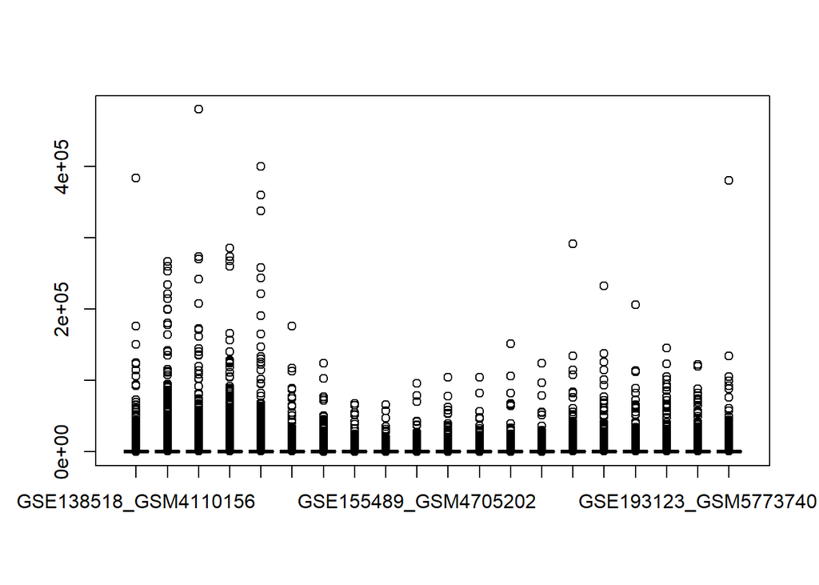

```r
boxplot(raw_data)
```

check the batch type

```r
table(batchType)
```

```
## batchType
## GSE138518 GSE155489 GSE193123
##         6         8         6
```

```r
batchType
```

```
##  [1] "GSE138518" "GSE138518" "GSE138518" "GSE138518" "GSE138518" "GSE138518"
##  [7] "GSE155489" "GSE155489" "GSE155489" "GSE155489" "GSE155489" "GSE155489"
## [13] "GSE155489" "GSE155489" "GSE193123" "GSE193123" "GSE193123" "GSE193123"
## [19] "GSE193123" "GSE193123"
```

```r
# the type of this allTab is a large matrix
rt <- allTab
rt <- as.data.frame(rt)
rt[1:5,1:5]
```

```
##          GSE138518_GSM4110156 GSE138518_GSM4110157 GSE138518_GSM4110158
## TSPAN6                    249                  962                 1034
## DPM1                      142                  642                  651
## SCYL3                      64                  231                  308
## C1orf112                   62                   92                   71
## FGR                        14                   20                   47
##          GSE138518_GSM4110159 GSE138518_GSM4110160
## TSPAN6                    953                  826
## DPM1                      982                  583
## SCYL3                     305                  223
## C1orf112                   60                   99
## FGR                       175                  530
```

```r
group_list1=c(rep('CT',3),rep('PC',3))
group_list2=c(rep('CT',4),rep('PC',4))
group_list3=c(rep('CT',3),rep('PC',3))
group_list=c(group_list1,group_list2,group_list3)
group_list=factor(group_list,levels=c('CT','PC'))

# a = grep('GSE138518',colnames(rt))
# b = grep('GSE155489',colnames(rt))
# c = grep('GSE193123',colnames(rt))
#
# exprSet=rt[,c(a,b,c)]
exprSet <- rt
```

```r
group_list
```

```
##  [1] CT CT CT PC PC PC CT CT CT CT PC PC PC PC CT CT CT PC PC PC
## Levels: CT PC
```

```r
table(group_list)
```

```
## group_list
## CT PC
## 10 10
```

```r
# condition is the grouping we need for our comparison, and type is our batch
coldata <- data.frame(condition = group_list, type = batchType)
coldata
```

```
##    condition      type
## 1         CT GSE138518
## 2         CT GSE138518
## 3         CT GSE138518
## 4         PC GSE138518
## 5         PC GSE138518
## 6         PC GSE138518
## 7         CT GSE155489
## 8         CT GSE155489
## 9         CT GSE155489
## 10        CT GSE155489
## 11        PC GSE155489
## 12        PC GSE155489
## 13        PC GSE155489
## 14        PC GSE155489
## 15        CT GSE193123
## 16        CT GSE193123
## 17        CT GSE193123
## 18        PC GSE193123
## 19        PC GSE193123
## 20        PC GSE193123
```

```r
rownames(coldata) <- colnames(exprSet)
coldata
```

```
##                      condition      type
## GSE138518_GSM4110156        CT GSE138518
## GSE138518_GSM4110157        CT GSE138518
## GSE138518_GSM4110158        CT GSE138518
## GSE138518_GSM4110159        PC GSE138518
## GSE138518_GSM4110160        PC GSE138518
## GSE138518_GSM4110161        PC GSE138518
## GSE155489_GSM4705199        CT GSE155489
## GSE155489_GSM4705200        CT GSE155489
## GSE155489_GSM4705201        CT GSE155489
## GSE155489_GSM4705202        CT GSE155489
## GSE155489_GSM4705203        PC GSE155489
## GSE155489_GSM4705204        PC GSE155489
## GSE155489_GSM4705205        PC GSE155489
## GSE155489_GSM4705206        PC GSE155489
## GSE193123_GSM5773736        CT GSE193123
## GSE193123_GSM5773737        CT GSE193123
## GSE193123_GSM5773738        CT GSE193123
## GSE193123_GSM5773739        PC GSE193123
## GSE193123_GSM5773740        PC GSE193123
## GSE193123_GSM5773741        PC GSE193123
```

```r
library(DESeq2)
dds <- DESeqDataSetFromMatrix(countData = exprSet,
                              colData = coldata,
                              design = ~ type+condition)
dds <- DESeq(dds)
resultsNames(dds)
```

```
## [1] "Intercept"                   "type_GSE155489_vs_GSE138518"
## [3] "type_GSE193123_vs_GSE138518" "condition_PC_vs_CT"
```

```r
res <- results(dds, name="condition_PC_vs_CT")
summary(res)
```

```
##
## out of 31595 with nonzero total read count
## adjusted p-value < 0.1
## LFC > 0 (up)       : 378, 1.2%
## LFC < 0 (down)     : 248, 0.78%
## outliers [1]       : 212, 0.67%
## low counts [2]     : 12180, 39%
## (mean count < 8)
## [1] see 'cooksCutoff' argument of ?results
## [2] see 'independentFiltering' argument of ?results
```

```r
DEG <- as.data.frame(res)
DEG <- DEG[order(DEG$pvalue),]
DEG = na.omit(DEG)
head(DEG)
```

```
##              baseMean log2FoldChange     lfcSE      stat       pvalue
## SREBF2-AS1  156.52551     -1.1141874 0.1505785 -7.399380 1.368215e-13
## SRSF7      2286.54848      0.5869620 0.1034029  5.676458 1.375120e-08
## GSTO1      1471.09837      0.8512325 0.1507910  5.645117 1.650690e-08
## PSMA5      1728.15188      0.6795506 0.1264652  5.373422 7.725624e-08
## CXCL2       345.36632      2.1921076 0.4179105  5.245400 1.559440e-07
## LGALS4       15.50059     -2.0154497 0.3849854 -5.235134 1.648656e-07
##                    padj
## SREBF2-AS1 2.627383e-09
## SRSF7      1.056607e-04
## GSTO1      1.056607e-04
## PSMA5      3.708879e-04
## CXCL2      4.366038e-04
## LGALS4     4.366038e-04
```

```r
save(DEG,file = "data/DESeq2_raw.Rdata")
write.table(DEG,row.names=TRUE,col.names=TRUE,sep=",","data/DESeq2_PCvsCT_raw.csv")
```

# pca plot

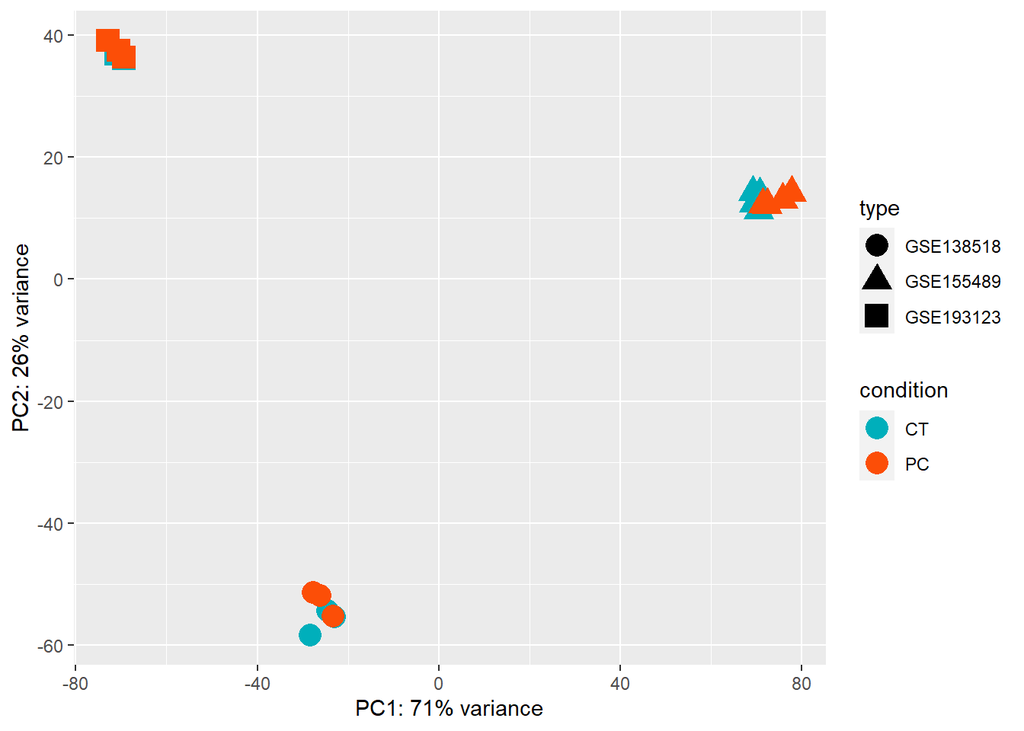

```r
library(ggplot2)
vsd <- vst(dds, blind=FALSE)
# the pca data contain details of pca information
pcaData <- plotPCA(vsd, intgroup=c("condition", "type"), returnData=TRUE)
# calculates the percentage of variance explained by each principal component in a PCA analysis stored in the pcaData object.
percentVar <- round(100 * attr(pcaData, "percentVar"))
color = c("#00AFBB","#FC4E07","#e6b707","#2874C5","#f87669","#868686","#92C5DE","#F4A582","#66C2A5","#FC8D62","#8DA0CB","#E78AC3","#A6D854","#FFD92F","#E5C494","#B3B3B3","#999999")
# the condition represent the disease type: PC and CT
# the type represent the sample name: gsexxxx
# Both scale_color_manual and scale_fill_manual are used to manually set color maps, but they apply to different graphic properties. The former is used to adjust the border color of the element, line color, etc., and the latter is used to set the fill color, such as the column color of the bar chart or the fill color below the area chart.
ggplot(pcaData, aes(PC1, PC2, color=condition, shape = type)) +
  scale_color_manual(values = color[1:nlevels(group_list)])+
  # scale_fill_manual(values = color[1:nlevels(group_list)])+
  geom_point(size=5)+
  # xlim(-80, 80) +
  # ylim(-60, 60) +
  xlab(paste0("PC1: ",percentVar[1],"% variance")) +
  ylab(paste0("PC2: ",percentVar[2],"% variance"))
```

```r
  # geom_text(aes(label=name),vjust=2)
```

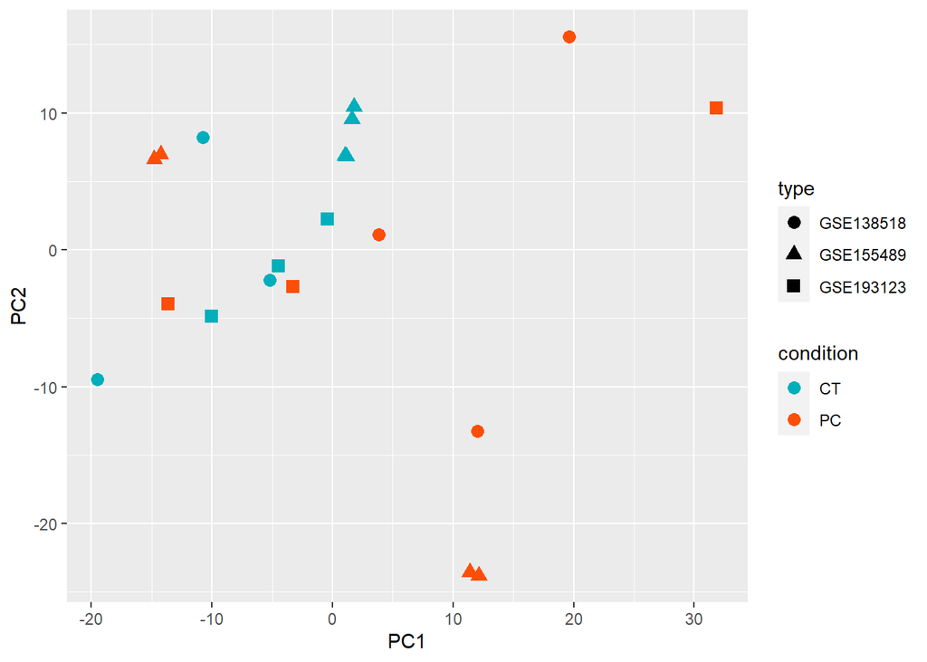

```r
assay(vsd) <- limma::removeBatchEffect(assay(vsd), vsd$type)
pcaData <- plotPCA(vsd, intgroup=c("condition", "type"), returnData=TRUE)
percentVar <- round(100 * attr(pcaData, "percentVar"))
ggplot(pcaData, aes(PC1, PC2, color=condition, shape = type)) +
  scale_color_manual(values = color[1:nlevels(group_list)])+
  geom_point(size=3)
```

```r
  # geom_text(aes(label=name),vjust=2)
```

```r
library(PDtools)
```

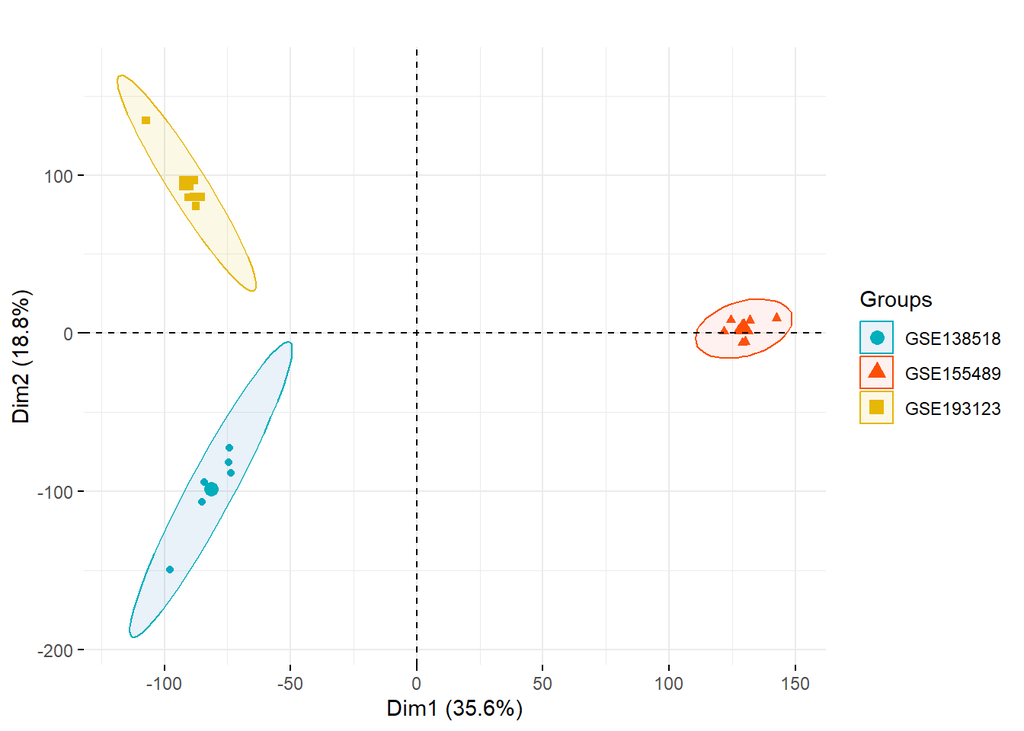

```r
# the tinyarray is package
vsd <- vst(dds, blind=FALSE)
dat <- assay(vsd)
Group <- factor(coldata$type,levels=c('GSE138518','GSE155489','GSE193123'))
# the dat has been log2
# alpha = 0.3: This sets the transparency level (alpha) of the ellipses. A value of 0.3 means the ellipses will be somewhat transparent.
# linetype = 2: This sets the line type of the ellipse's border. A value of 2 specifies a dashed line type.
pca.plot = draw_pca(dat,Group)+
  scale_color_manual(values = color[1:3])
      # stat_ellipse(aes(color = Group,fill = Group),
      #              geom = "polygon",
      #              alpha = 0.3,
      #              linetype = 2)
pca.plot
```

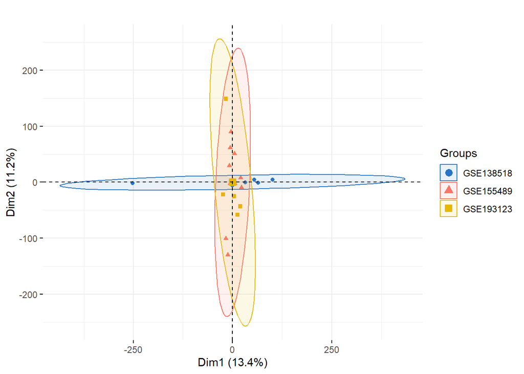

```r
library(PDtools)
assay(vsd) <- limma::removeBatchEffect(assay(vsd), vsd$type)
# the tinyarray is package
dat <- assay(vsd)
Group <- factor(coldata$type,levels=c('GSE138518','GSE155489','GSE193123'))
# the dat has been log2
# alpha = 0.3: This sets the transparency level (alpha) of the ellipses. A value of 0.3 means the ellipses will be somewhat transparent.
# linetype = 2: This sets the line type of the ellipse's border. A value of 2 specifies a dashed line type.
pca.plot = draw_pca(dat,Group)
      # stat_ellipse(aes(color = Group,fill = Group),
      #              geom = "polygon",
      #              alpha = 0.3,
      #              linetype = 2)
pca.plot
```

# pheatmap

```r
group_list1=c(rep('CT',3),rep('PC',3))
group_list2=c(rep('CT',4),rep('PC',4))
group_list3=c(rep('CT',3),rep('PC',3))
group_list=c(group_list1,group_list2,group_list3)
group_list=factor(group_list,levels=c('CT','PC'))
dat <- limma::removeBatchEffect(exprSet, vsd$type)
dat1 <- exprSet[,group_list=="CT"]

dat2 <- exprSet[,group_list=="PC"]

dat <- cbind(dat1,dat2)

library(limma)
dat <- log2(dat+1)
group_list = factor(c(rep("CT",10),rep("PC",10)),levels=c('CT','PC'))
# cg=names(tail(sort(apply(dat,1,sd)),1000))#apply按行（'1'是按行取，'2'是按列取）取每一行的方差，从小到大排序，取最大的1000个
```

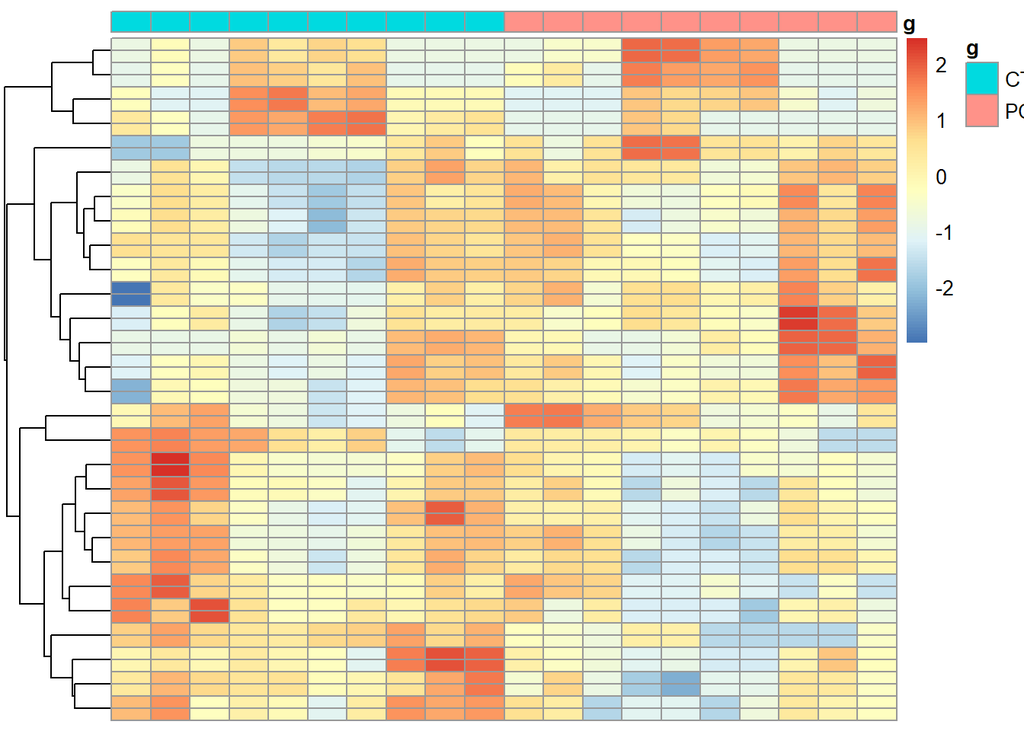

```r
###差异基因名称提取
DEG_genes <- DEG[DEG$padj<0.01&abs(DEG$log2FoldChange)>1.5,]
DEG_sorted <- DEG_genes[order(DEG_genes$log2FoldChange,decreasing = T), ]
tem1 <- head(rownames(DEG_sorted),50)
tem2 <- tail(rownames(DEG_sorted),50)
# 我们需要降序
library(pheatmap)
n=t(scale(t(dat[c(tem1,tem2),]))) # 'scale'可以对log-ratio数值进行归一化
# cg=names(tail(sort(apply(dat,1,sd)),1000))#apply按行（'1'是按行取，'2'是按列取）取每一行的方差，从小到大排序，取最大的1000个
# n=t(scale(t(dat[cg,])))
# n[n>2]=2
# n[n< -2]= -2
# pheatmap(n,show_colnames =F,show_rownames = F)
ac=data.frame(g=group_list)
rownames(ac)=colnames(n) #把ac的行名给到n的列名，即对每一个探针标记上分组信息（是'noTNBC'还是'TNBC'）
## 可以看到TNBC具有一定的异质性，拿它来区分乳腺癌亚型指导临床治疗还是略显粗糙。
# pheatmap(n,show_colnames =F,show_rownames = F,
#          annotation_col=ac,filename = './Figure1//heatmap_top1000_sd.png')
pheatmap(n,show_colnames =F,show_rownames = F,annotation_col=ac,cluster_cols = F)
```

this way the pheatmap is not good enough

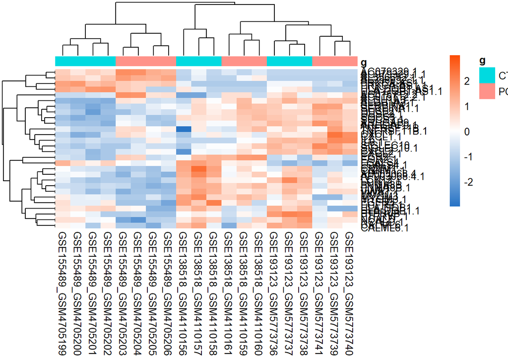

```r
DEG_gene_expr <- dat[c(tem1,tem2),]
# DEG_gene_expr <- t(scale(t(DEG_gene_expr)))
# png(paste0(job,'3mVS9M_DEG_pheatmap.png'),width =1024,height =1024)
pheatmap(DEG_gene_expr,color=colorRampPalette(c("#2874C5","white","#FC4E07"))(100),
         scale="row",
         border_color=NA,
         fontsize=10,
         show_rownames=T,
         annotation_col=ac)
```